# Informe de proyecto: Algoritmo de agrupamiento

Ricard Trinchet Arnejo

Enero 2019

# Agrupamiento

```r
library(tidyverse)
library(cluster)
library(gridExtra)
library(corrplot)
library(GGally)
```

## Objetivo

El objetivo de esta sección se corresponde con el estudio de la existencia de posibles grupos dentro de los clientes particulares y empresas que compran productos en la cadena. De este modo, se busca detectar posibles grupos de consumidores a los que destinar ofertas y promociones.

## Preparación de los datos

```r
clientes_unicos <- cl_prod %>%
  group_by(cod.cliente) %>%
  mutate(beneficio = sum(beneficio), unidades.media = mean(total.unidades),
          suma.importe = sum(importe.total), importe.medio = mean(importe.total)) %>%
  as.data.frame() %>%
  select(nombre.cliente, sexo, total.compras, puntos.acumulados,
                             unidades.media, suma.importe, importe.medio, beneficio, numero.hijos) %>%
  unique()
```

Observamos que en este conjunto de datos hay valores para empresas y clientes particulares. Procedemos a separar ambos conjuntos.

```r
empresas <- clientes_unicos %>% filter(sexo == 'Empresa') %>% select(-c(sexo, numero.hijos))

clientes_unicos <- clientes_unicos %>% filter(sexo != 'Empresa')
```

Puesto que las empresas y los clientes particulares deberían presentar comportamientos distintos en las compras, prodeceremos a analizar ambos grupos de manera separada.

## Clientes particulares

### Estudio de los clientes

#### Histogramas

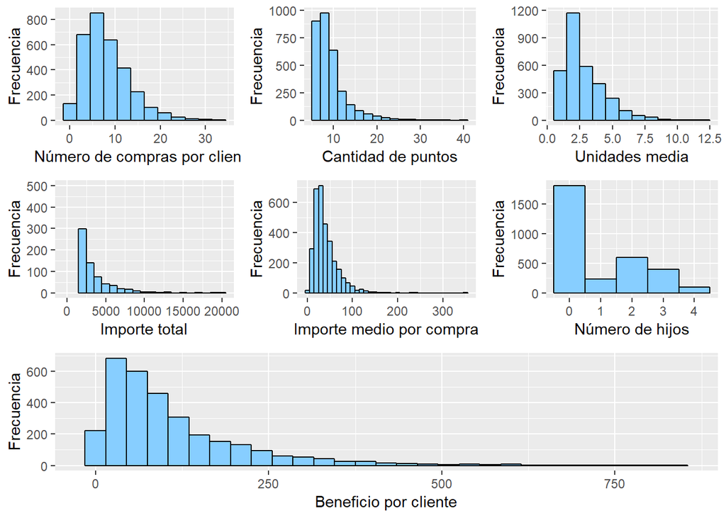

```r
# plots histogramas

# Histogram of Compras
p1 <- ggplot(clientes_unicos, aes(x=total.compras)) +
  geom_histogram(binwidth=3, fill="skyblue1", colour="black") +
  labs(x="Número de compras por cliente", y="Frecuencia")

# Histogram of puntos.acumulados
p2 <- ggplot(clientes_unicos, aes(x=puntos.acumulados)) +
  geom_histogram(binwidth=2, fill="skyblue1", colour="black") +
  labs(x="Cantidad de puntos", y="Frecuencia")

# Histogram of unidades.media
p3 <- ggplot(clientes_unicos, aes(x=unidades.media)) +
  geom_histogram(binwidth=1, fill="skyblue1", colour="black") +
  labs(x="Unidades media", y="Frecuencia")

# Histogram of suma.importe
p4 <- ggplot(clientes_unicos, aes(x=suma.importe)) +
  geom_histogram(binwidth = 1000, fill="skyblue1", colour="black") +
  labs(x="Importe total", y="Frecuencia") + ylim(0,500)


# Histogram of importe.medio
p5 <- ggplot(clientes_unicos, aes(x=importe.medio)) +
  geom_histogram(binwidth=10, fill="skyblue1", colour="black") +
  labs(x="Importe medio por compra", y="Frecuencia")

# Histogram of numero.hijos
p6 <- ggplot(clientes_unicos, aes(x=numero.hijos)) +
  geom_histogram(binwidth=1, fill="skyblue1", colour="black") +
  labs(x="Número de hijos", y="Frecuencia")

# Histogram of beneficio
p7 <- ggplot(clientes_unicos, aes(x=beneficio)) +
  geom_histogram(binwidth=30, fill="skyblue1", colour="black") +
  labs(x="Beneficio por cliente", y="Frecuencia")



# Subplot with all the histograms
grid.arrange(p1, p2, p3, p4, p5, p6, p7,
             layout_matrix=cbind(c(1,4,7), c(2,5,7), c(3,6,7)))
```

Podemos observar las distribuciones de las diferentes variables que utilizaremos en el algoritmo de clustering. Destaca que el valor más frecuente para el número de hijos es 0.

#### Matriz de correlación

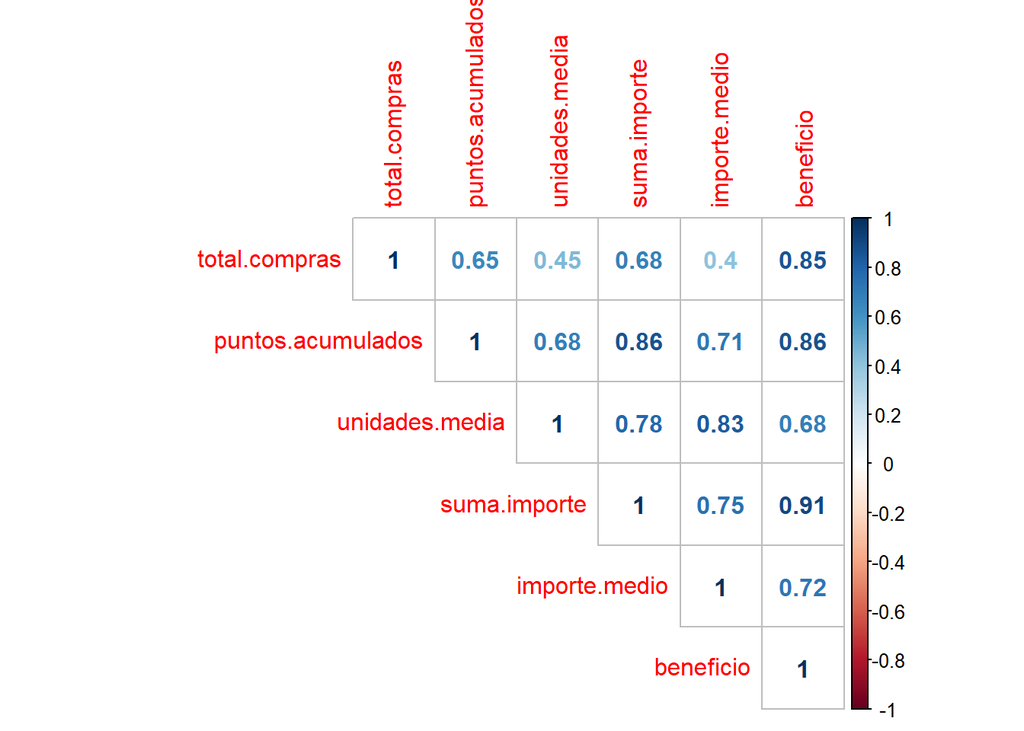

```r
#correlation matrix
clientes_unicos %>% select(-c(nombre.cliente, sexo, numero.hijos))  %>% cor() %>% corrplot( type="upper", method="number", tl.cex=1)
```

Existe una alta correlación entre `beneficio` y variables como `suma.importe`,`puntos.acumulados` o `total.compras`, lo cual es bastante razonable teniendo en cuenta como hemos definido la variable `beneficio`.

### Algoritmo de agrupamiento

Mostramos un `summary` de la tabla con la que trabajaremos.

```r
clientes.normalizado <- clientes_unicos %>% select(-c(nombre.cliente, sexo)) %>%
  scale() %>% as.data.frame()

summary(clientes.normalizado)
```

```
##  total.compras     puntos.acumulados unidades.media     suma.importe
##  Min.   :-1.4203   Min.   :-1.2269   Min.   :-1.1686   Min.   :-0.62485
##  1st Qu.:-0.8207   1st Qu.:-0.7042   1st Qu.:-0.7449   1st Qu.:-0.52150
##  Median :-0.2212   Median :-0.1814   Median :-0.3213   Median :-0.37325
##  Mean   : 0.0000   Mean   : 0.0000   Mean   : 0.0000   Mean   : 0.00000
##  3rd Qu.: 0.5783   3rd Qu.: 0.3413   3rd Qu.: 0.5145   3rd Qu.: 0.07692
##  Max.   : 4.9751   Max.   : 7.9208   Max.   : 5.7181   Max.   :11.17892
##  importe.medio       beneficio        numero.hijos
##  Min.   :-1.4153   Min.   :-1.0296   Min.   :-0.7711
##  1st Qu.:-0.6660   1st Qu.:-0.6705   1st Qu.:-0.7711
##  Median :-0.2733   Median :-0.3071   Median :-0.7711
##  Mean   : 0.0000   Mean   : 0.0000   Mean   : 0.0000
##  3rd Qu.: 0.4256   3rd Qu.: 0.3247   3rd Qu.: 0.8297
##  Max.   :12.0873   Max.   : 6.9280   Max.   : 2.4305
```

A continuación, utilizamos la **elbow rule** para determinar el número adecuado de clusters que escoger.

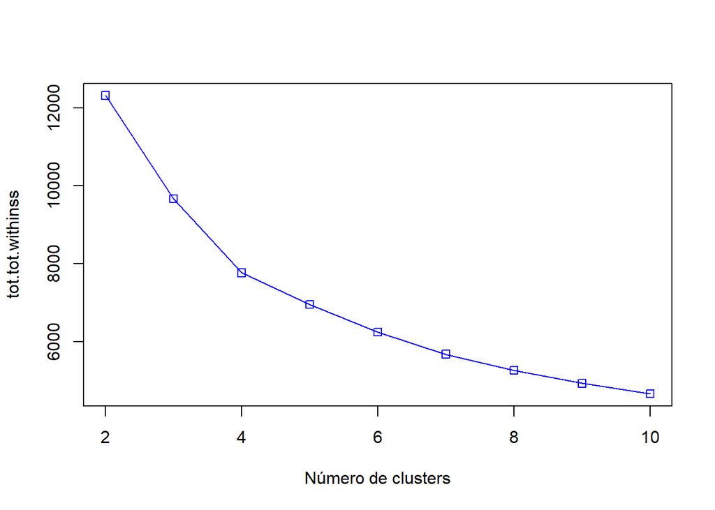

```r
## num clusters adecuado -----------------

## buscar total withinness
# en este caso: k=4 -- elbow rule
set.seed(123)
resultados <- rep(0, 10)
for (i in c(2,3,4,5,6,7,8,9,10))
{
  fit           <- kmeans(clientes.normalizado, i, nstart=20)
  resultados[i] <- fit$tot.withinss
}
plot(2:10,resultados[2:10],type="o",col="blue",pch=0,xlab="Número de clusters",ylab="tot.tot.withinss")
```

En este caso, el número seleccionado es 4. Procedemos a efectuar el método **k-means**.

```r
# k = 4
set.seed(123)

kmeans.k4 <- kmeans(clientes.normalizado, centers=4, nstart=20)

# medida de adecuación del algoritmo
kmeans.k4$tot.withinss
```

```
## [1] 7764.261
```

La medida total withinss nos indica lo bien que funciona el algoritmo para este conjunto de datos.

Visualizamos los resultados obtenidos con el método mediante distintas gráficas.

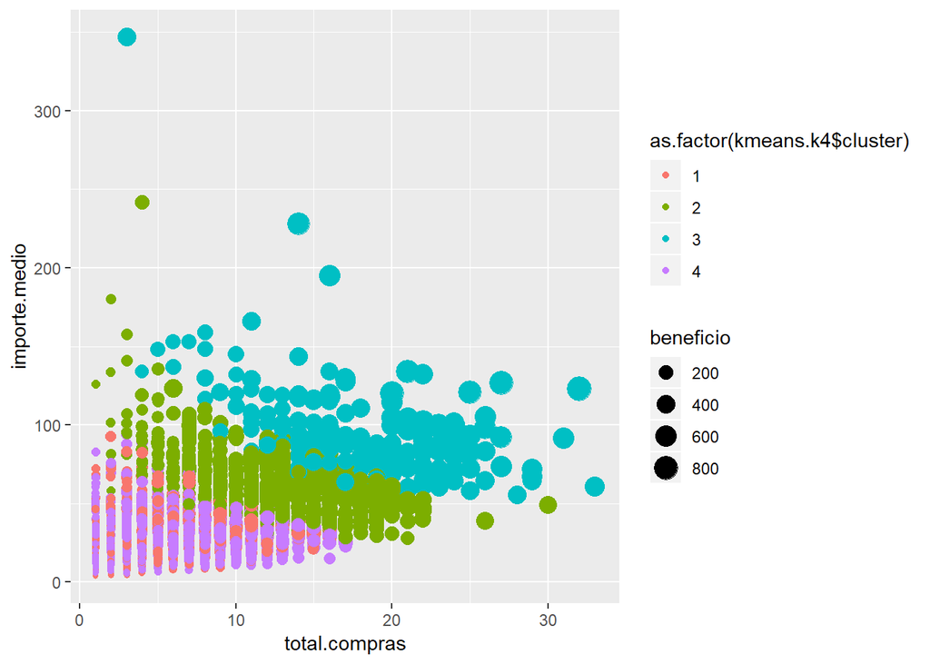

```r
# grafica de clusters : compras vs importe; size: beneficio
ggplot(clientes_unicos, aes(x=total.compras, y = importe.medio,
                                 color = as.factor(kmeans.k4$cluster), size = beneficio)) +
  geom_point() ### mayor beneficio en el cluster 3
```

En esta gráfica, se representa el número total de compras frente al importe medio gastado por cada cliente. Se representan los 4 clústers obtenidos. El radio de los puntos indica el beneficio obtenido con cada cliente. Observamos como los clientes del grupo 3 son los que mayor beneficio aportan al negocio.

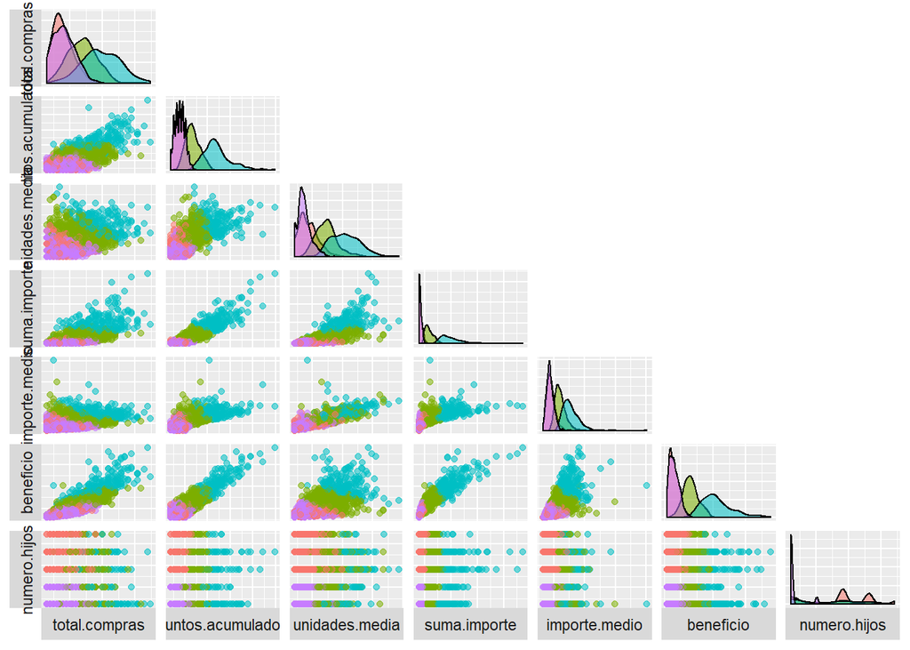

```r
ggpairs(cbind(clientes.normalizado, Cluster=as.factor(kmeans.k4$cluster)),
        columns=1:7, aes(colour=Cluster, alpha=0.5),
        lower=list(continuous="points"),
        upper=list(continuous="blank"),
        axisLabels="none", switch="both")
```

Esta última gráfica nos permite apreciar los clusters creados por el método cruzando todas las variables utilizadas. Apreciamos como los clusters 1 y 4 presentan valores muy semejantes en todas las variables. La única diferencia es que los miembros del cluster 4 son los que no tienen hijos mientras que los del cluster 1 tienen algún hijo.

### **Información segmentada por clusters**

Ahora, incorporaremos la información sobre los clusters a la tabla original, para obtener datos de cada clúster en particular y poder entender un poco mejor como se separan los grupos.

```r
# añadimos info de clusters a la tabla original

clientes_unicos <- clientes_unicos %>% mutate(cluster = kmeans.k4$cluster)
```

```r
# incluir informacion sobre todas las variables!!!---------------
clusters_clientes_informacion <- clientes_unicos %>% group_by(cluster) %>%
  summarise(numero.compras=mean(total.compras), puntos.acumulados = mean(puntos.acumulados),
            unidades.media = mean (unidades.media), suma.importe = mean (suma.importe),
            importe.medio = mean (importe.medio), beneficio = mean(beneficio),
            numero.hijos = mean(numero.hijos))
```

**Visualizaciones**:

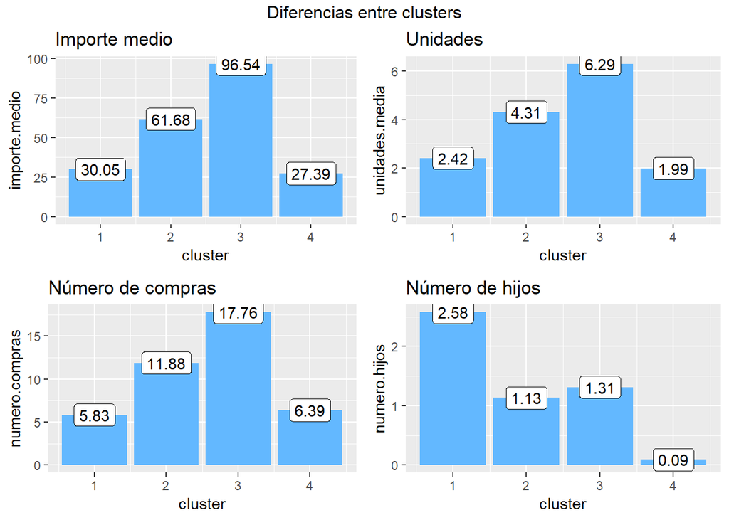

```r
# plots de clusters -------------

options(digits=2)

# importe medio
p1 <- ggplot(clusters_clientes_informacion, aes(x=cluster, y=importe.medio)) +
  geom_bar(stat="identity", fill="steelblue1", show.legend=FALSE) +
  geom_label(aes(label=format(round(importe.medio, 2), nsmall = 2))) +
  labs(title="Importe medio")


# uds media
p2 <- ggplot(clusters_clientes_informacion, aes(x=cluster, y=unidades.media)) +
  geom_bar(stat="identity", fill="steelblue1", show.legend=FALSE) +
  geom_label(aes(label=round(unidades.media, 2))) +
  labs(title="Unidades")

# numero compras
p3 <- ggplot(clusters_clientes_informacion, aes(x=cluster, y=numero.compras)) +
  geom_bar(stat="identity", fill="steelblue1", show.legend=FALSE) +
  geom_label(aes(label=round(numero.compras, 2))) +
  labs(title="Número de compras")

# hijos
p4 <- ggplot(clusters_clientes_informacion, aes(x=cluster, y=numero.hijos)) +
  geom_bar(stat="identity", fill="steelblue1", show.legend=FALSE) +
  geom_label(aes(label=round(numero.hijos, 2))) +
  labs(title="Número de hijos")

# Subplot with all the histograms
grid.arrange(p1, p2, p3, p4, ncol = 2, top =  'Diferencias entre clusters')
```

## Empresas

Llevamos a cabo un estudio análogo para las empresas que compran en la cadena.

En este caso, prescindimos de la variable número de hijos, puesto que no procede.

Obtenemos valores muy similares en las visualizaciones siguientes.

### Estudio de las empresas

#### Histogramas

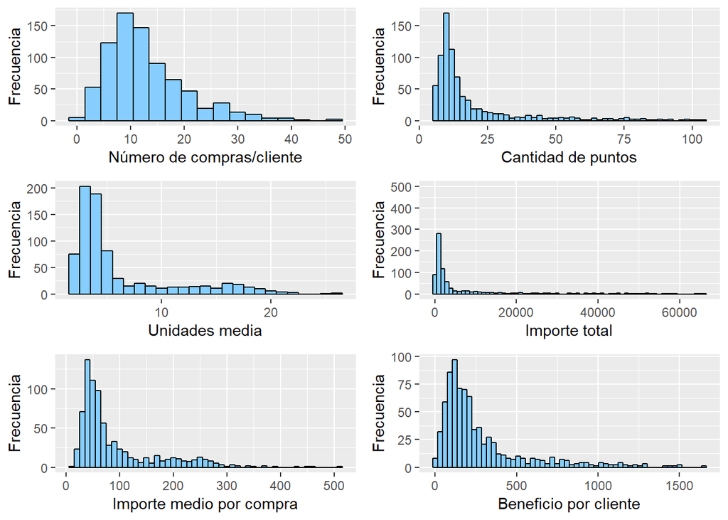

```r
#plots histogramas---------

# Histogram of Compras
p1 <- ggplot(empresas, aes(x=total.compras)) +
  geom_histogram(binwidth=3, fill="skyblue1", colour="black") +
  labs(x="Número de compras/cliente", y="Frecuencia")

# Histogram of puntos.acumulados
p2 <- ggplot(empresas, aes(x=puntos.acumulados)) +
  geom_histogram(binwidth=2, fill="skyblue1", colour="black") +
  labs(x="Cantidad de puntos", y="Frecuencia")

# Histogram of unidades.media
p3 <- ggplot(empresas, aes(x=unidades.media)) +
  geom_histogram(binwidth=1, fill="skyblue1", colour="black") +
  labs(x="Unidades media", y="Frecuencia")

# Histogram of suma.importe
p4 <- ggplot(empresas, aes(x=suma.importe)) +
  geom_histogram(binwidth = 1000, fill="skyblue1", colour="black") +
  labs(x="Importe total", y="Frecuencia") + ylim(0,500)


# Histogram of importe.medio
p5 <- ggplot(empresas, aes(x=importe.medio)) +
  geom_histogram(binwidth=10, fill="skyblue1", colour="black") +
  labs(x="Importe medio por compra", y="Frecuencia")


# Histogram of beneficio
p6 <- ggplot(empresas, aes(x=beneficio)) +
  geom_histogram(binwidth=30, fill="skyblue1", colour="black") +
  labs(x="Beneficio por cliente", y="Frecuencia")



# Subplot with all the histograms
grid.arrange(p1, p2, p3, p4, p5, p6,
             ncol = 2)
```

#### Matriz de correlación

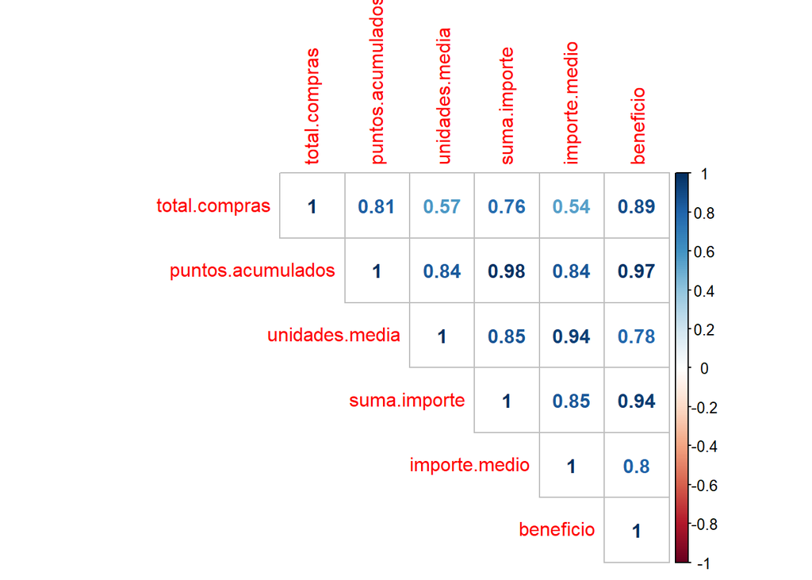

```r
#correlation matrix
empresas %>% select(-c(nombre.cliente))  %>% cor() %>% corrplot( type="upper", method="number", tl.cex=1)
```

### Algoritmo de agrupamiento

Comenzamos normalizando los datos de las empresas y mostrando los datos.

```r
empresas.normalizado <- empresas %>% select(-c(nombre.cliente)) %>%
  scale() %>% as.data.frame()

summary(empresas.normalizado)
```

```
##  total.compras  puntos.acumulados unidades.media  suma.importe
##  Min.   :-1.6   Min.   :-0.8      Min.   :-0.9   Min.   :-0.6
##  1st Qu.:-0.7   1st Qu.:-0.5      1st Qu.:-0.6   1st Qu.:-0.5
##  Median :-0.2   Median :-0.4      Median :-0.4   Median :-0.4
##  Mean   : 0.0   Mean   : 0.0      Mean   : 0.0   Mean   : 0.0
##  3rd Qu.: 0.4   3rd Qu.: 0.0      3rd Qu.: 0.1   3rd Qu.:-0.1
##  Max.   : 4.7   Max.   : 4.7      Max.   : 4.0   Max.   : 5.0
##  importe.medio    beneficio
##  Min.   :-1.1   Min.   :-1.0
##  1st Qu.:-0.6   1st Qu.:-0.6
##  Median :-0.4   Median :-0.3
##  Mean   : 0.0   Mean   : 0.0
##  3rd Qu.: 0.2   3rd Qu.: 0.2
##  Max.   : 5.5   Max.   : 5.1
```

A continuación, utilizamos la **elbow rule** para determinar el número adecuado de clusters que escoger.

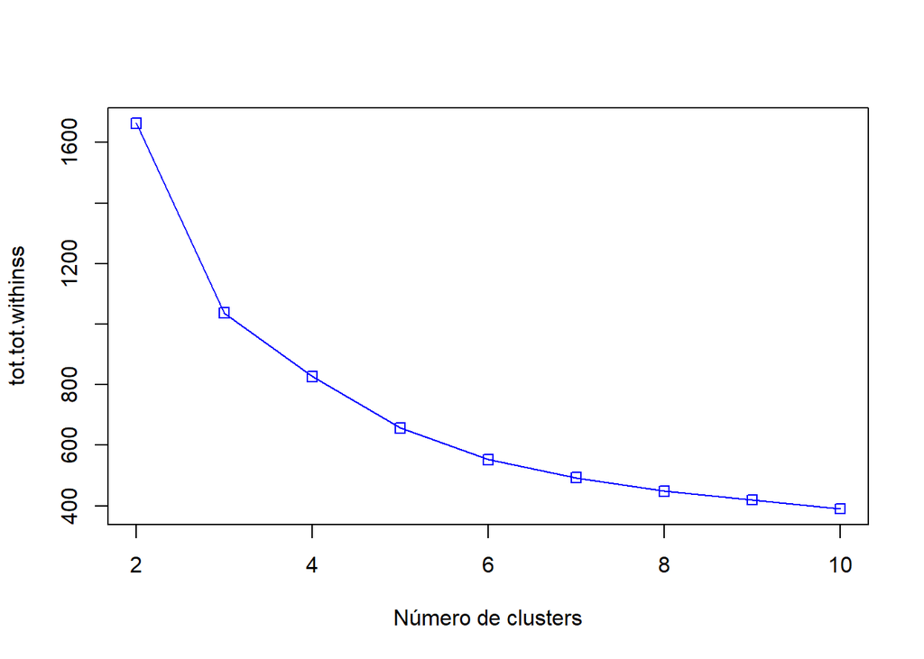

```r
## num clusters adecuado -----------------

# en este caso: k=3 -- elbow rule
set.seed(123)
resultados <- rep(0, 10)
for (i in c(2,3,4,5,6,7,8,9,10))
{
  fit           <- kmeans(empresas.normalizado, i, nstart=20)
  resultados[i] <- fit$tot.withinss
}
plot(2:10,resultados[2:10],type="o",col="blue",pch=0,xlab="Número de clusters",ylab="tot.tot.withinss")
```

```r
## k = 3

set.seed(123)

kmeans.k3 <- kmeans(empresas.normalizado, centers=3, nstart=20)


# medida de adecuación del algoritmo
kmeans.k3$tot.withinss
```

```
## [1] 1037
```

La medida total withinss nos indica lo bien que funciona el algoritmo para este conjunto de datos. En el caso de las empresas, este valor es más pequeño que en el caso de los clientes particulares, lo cual indica que el algortimo funciona mejor para este caso.

Nuevamente, visualizamos los resultados obtenidos con el método mediante distintas gráficas.

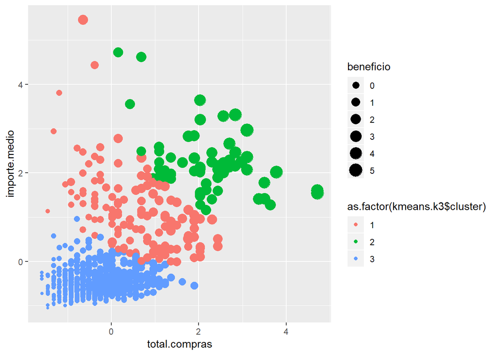

```r
# grafica de clusters : compras vs importe; size: beneficio
ggplot(empresas.normalizado, aes(x=total.compras, y = importe.medio,
                            color = as.factor(kmeans.k3$cluster), size = beneficio)) +
  geom_point() ### mayor beneficio en el cluster 3
```

En esta gráfica, ya se aprecia una mejor segmentación que en el caso de clientes particulares, pues los clusters parece que separan mejor el beneficio.

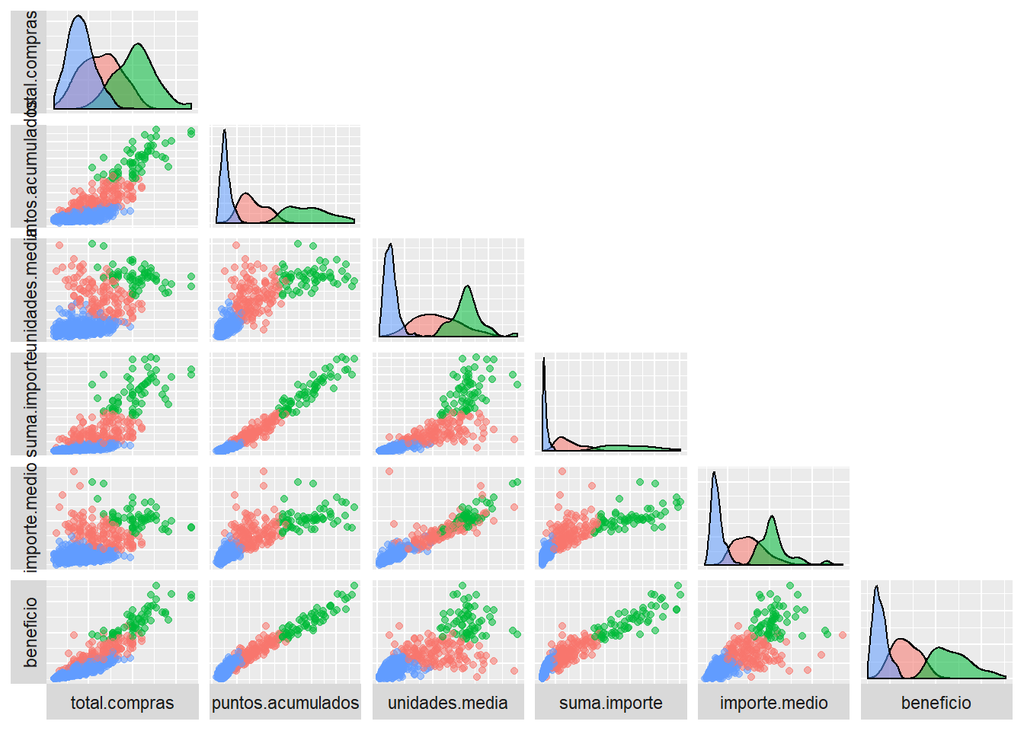

```r
### incluir info sobre clusters --- columns = 1:7
ggpairs(cbind(empresas.normalizado, Cluster=as.factor(kmeans.k3$cluster)),
        columns=1:6, aes(colour=Cluster, alpha=0.5),
        lower=list(continuous="points"),
        upper=list(continuous="blank"),
        axisLabels="none", switch="both")
```

### **Información segmentada por clusters**

De nuevo, incorporaremos la información sobre los clusters a la tabla original, para obtener datos de cada clúster en particular y poder entender un poco mejor como se separan los grupos.

```r
### añadimos info de clusters a la tabla original---------


empresas <- empresas %>% mutate(cluster = kmeans.k3$cluster)
```

```r
## informacion por clusters -------


clusters_empresas_informacion <- empresas %>% group_by(cluster) %>%
  summarise(numero.compras=mean(total.compras), puntos.acumulados = mean(puntos.acumulados),
            unidades.media = mean (unidades.media), suma.importe = mean (suma.importe),
            importe.medio = mean (importe.medio), beneficio = mean(beneficio))
```

*Visualizaciones*:

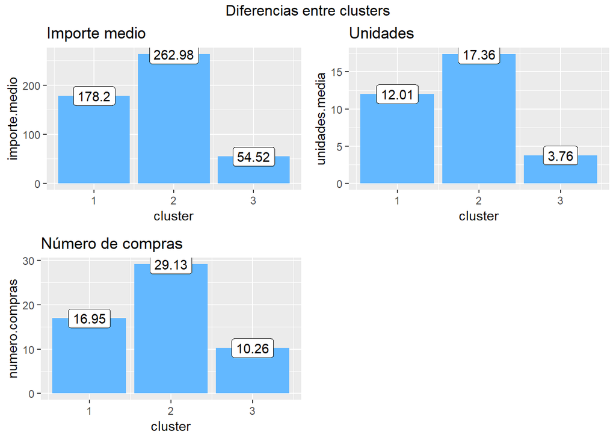

```r
# plots de clusters -------------


# importe medio
p1 <- ggplot(clusters_empresas_informacion, aes(x=cluster, y=importe.medio)) +
  geom_bar(stat="identity", fill="steelblue1", show.legend=FALSE) +
  geom_label(aes(label=round(importe.medio, 2))) +
  labs(title="Importe medio")


# uds media
p2 <- ggplot(clusters_empresas_informacion, aes(x=cluster, y=unidades.media)) +
  geom_bar(stat="identity", fill="steelblue1", show.legend=FALSE) +
  geom_label(aes(label=round(unidades.media, 2))) +
  labs(title="Unidades")

# numero compras
p3 <- ggplot(clusters_empresas_informacion, aes(x=cluster, y=numero.compras)) +
  geom_bar(stat="identity", fill="steelblue1", show.legend=FALSE) +
  geom_label(aes(label=round(numero.compras, 2))) +
  labs(title="Número de compras")



# Subplot with all the histograms
grid.arrange(p1, p2, p3, ncol = 2, top =  'Diferencias entre clusters')
```

Observamos una separación similar a la de clientes particulares, simplemente eliminando el cluster relativo a los clientes con hijos.

## Sugerencias para el negocio

Una vez hemos identificado los distintos grupos y sabemos a cual pertenece cada cliente, podemos realizar una serie de propuestas, observando las características medias de cada grupo.

Por ejemplo, los clientes particulares que pertenecen al grupo 2, compran 4 unidades de media por compra, gastan 61, efectuaron 11 compras y tienen 1 hijo. Por tanto, mediante esta información, sabemos categorizar su consumo y podemos orientar alguna campaña exclusiva a este grupo. Así, podríamos hacer con todos los distintos grupos.